# United in Diversity, Divided by Algorithms?A Cross-National Examination of the Role of Ad Delivery Algorithms during the 2024 European Parliament Election

### Fabio Votta, Simon Kruschinski, Mads Fuglsang Hove, Anamaria Dutceac Segesten, Márton Bene, Christina Gahn, Linn Sandberg, Jan Zilinsky, Claes de Vreese, James P. Cross, Ruth Dassonneville, Tom Dobber, Benjamin Guinaudeau

# Introduction

The health of representative democracy relies on competitive elections in which parties can meaningfully contest for voter support. Ensuring this requires a level playing field that offers political actors fair opportunities to reach and persuade the electorate. Traditionally regulatory frameworks have responded to this need by creating rules for financial expenditure and transparency obligations.

However, the rise of social media has transformed campaign strategies. Platforms like Facebook now offer powerful tools for voter outreach, particularly through targeted advertising. Yet unlike traditional media, online political advertising operates with minimal oversight (Helberger, Dobber, & de Vreese, 2021). The cost of political advertisements is determined by ad auctions, whose decision mechanisms are vague and opaque (Votta et al. 2024). We argue that this automation threatens political equality by introducing biases that can systematically favor certain parties and constituencies.

**RQ1:** How do prices for political ads vary?  
**RQ2:** What factors influence price differences?

# Design: Algorithm Audit Study

- 2024 European Parliament election
- 30 political parties in 8 countries (incl. 3 European parties, each advertising in 5 countries)
- Facebook ads ran 7 days from April 29, 2024 - 1€ daily budget per ad (105€ per party, €525 for European parties)
- Identical GOTV ads using **official party accounts**
- Each Party X Country = 15 ads (3 audiences × 5 ad copies) - in total 630 ads
- DV: **Cost per 1,000 unique users reached (CPM)**

**3 targeting conditions:**  
– Interest in Politics  
– Below-University Education  
– No Targeting

**3 potential influence factors:**  
– Market-level factors  
– Party-level factors  
– Account-level factors

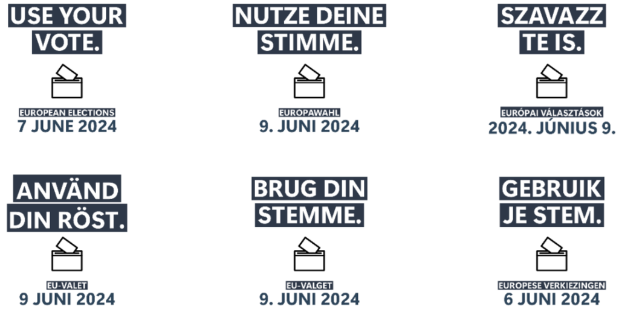

*GOTV ads used in Study*

# Main Results

### Country Level Differences

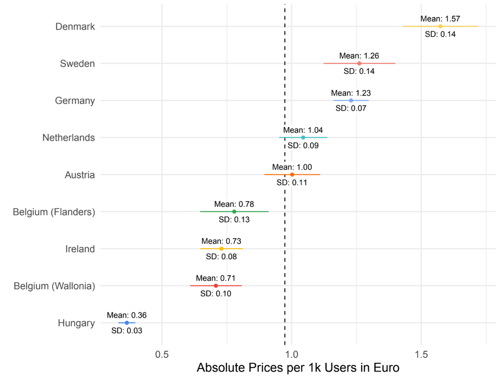

Large CPM differences across countries, with up to **332%** between Denmark and Hungary. On average, countries differed by **56%** despite identical ad content and budgets.

### Party & Audience Level Differences

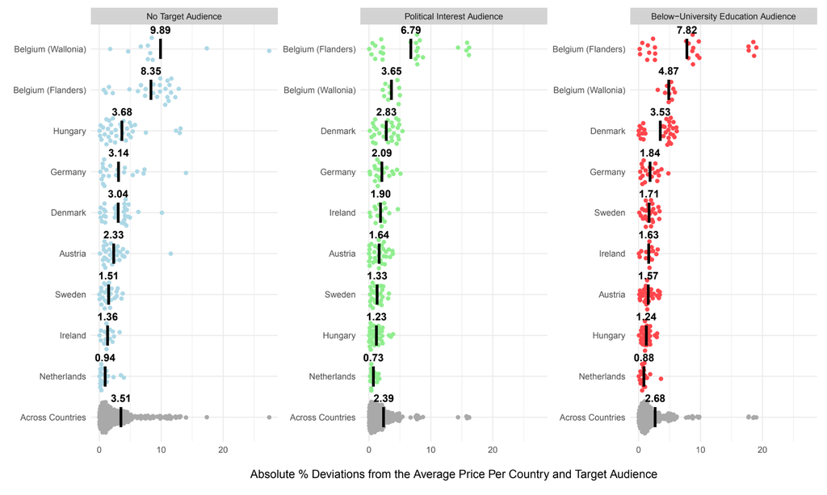

### Multilevel Models: DV = Cost per 1,000 users

| Coefficients | Model 1 | Model 2 | Model 3 | Model 4 |
| --- | --- | --- | --- | --- |
| **Fixed Effects** |  |  |  |  |
| Intercept | **0.974*** (0.064)** | **0.966*** (0.137)** | **0.966*** (0.137)** | 0.998 (0.684) |
| Times Ad was Shown |  |  |  | **0.651*** (0.053)** |
| Engagements |  |  |  | **0.008* (0.003)** |
| Total Spent on Ad |  |  |  | -0.101 (0.095) |
| **Random Effects (SD)** |  |  |  |  |
| Audience-Level Price SD | 0.107 | 0.110 | 0.110 | 0.119 |
| Within-Country Price SD | 0.382 | 0.056 | 0.044 | 0.038 |
| Country-Level Price SD |  | 0.363 | 0.362 | 0.371 |
| Party-Level Price SD |  |  | 0.039 | 0.041 |

**Note:** Model 1 includes a random intercept for the target audience only. Model 2 adds a random intercept for each country. Model 3 introduces a nested random intercept structure for parties within countries. Model 4 adds fixed effects for ad engagement, total ad spend, and impressions. Random intercepts represent price variation by country, audience, and party. Within-country SD captures unexplained national variation.*** p < 0.001; ** p < 0.01; * p < 0.05.

# Exploratory Findings

### Price Differences by Age

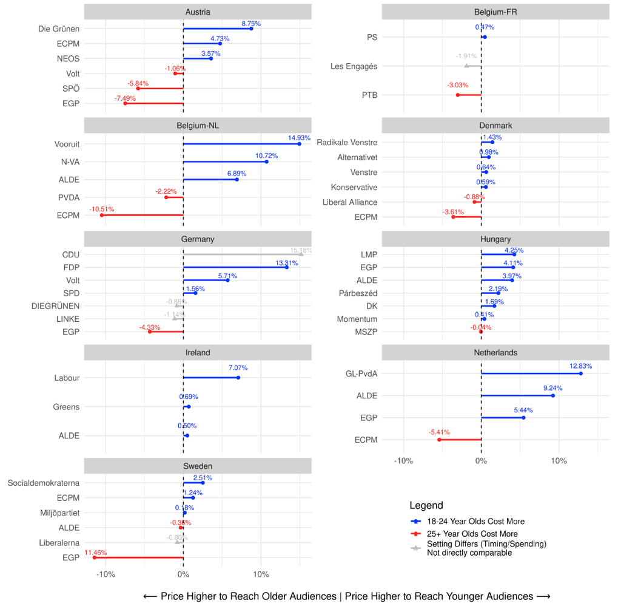

Reaching younger users (18–24) tends to be more expensive compared to reaching older age groups but pricing difference depends on party.

### Price Differences by Gender

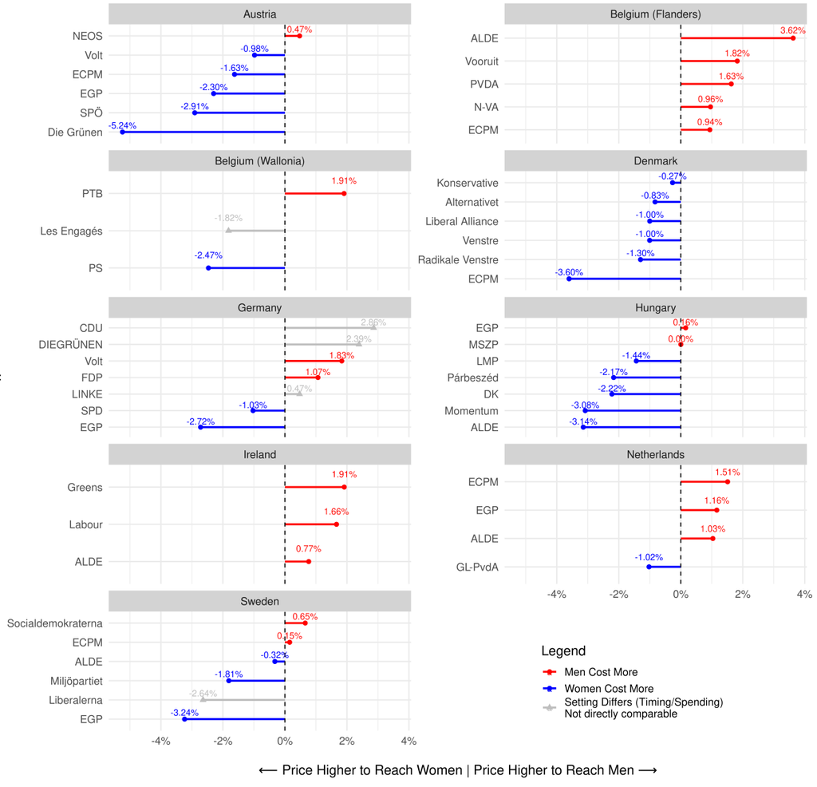

Gender-based pricing shows no consistent pattern and varies substantially within different countries.

*Note:* exploratory graphs here **include** parties (in grey) that did not run ads at the same time or spend less so comparison should be careful.

# What Correlates with Prices?

### Multilevel Models: DV = Cost per 1,000 users

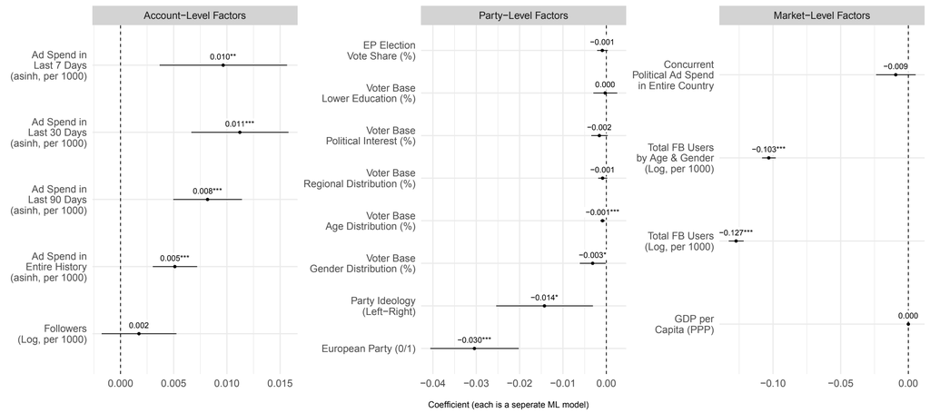

Account-level factors such as *recent* and *historical ad spending* are positively associated with higher prices. This means larger spenders are charged more and smaller spenders are charged less.  
Party-level patterns suggest that **European party accounts** and **right-leaning parties** may receive lower prices. **Alignment between the party’s voter base and the reached audience** (e.g., if the reached audience aligns with the voter base in terms of age and gender) is *weakly* associated with cost reductions, though coefficients are *small* and not always *statistically significant*.  
Market-level factors show that **larger audience sizes** tend to face *lower prices*, possibly due to broader supply and/or reduced competition for views.

# Conclusion

**Unequal Playing Field:** Algorithmic pricing introduces substantial variation in the cost of reaching voters. Even with identical content and budgets, these differences can distort political competition and influence which citizens are more likely to be reached or excluded.

**Transparency Gap:** Current regulation and transparency tools overwhelmingly focus on *what* content is shown and *who* is targeted. However, they neglect the crucial role of *how* ads are delivered by ad delivery algorithms. These systems not only shape prices, but also affect the final audience composition of political messages. Our findings suggest that platform-controlled delivery decisions can lead to systematic price and reach differences without advertisers’ knowledge, and without public accountability.

**Policy Implications:** While the Digital Services Act mandates transparency around political advertising, ad delivery algorithms remain a blind spot. Ad libraries should be extended to include metadata on optimization goals and delivery parameters. Crucially, platforms currently optimize ad delivery for *commercial outcomes*. This logic may be appropriate in consumer markets, for instance in cases where a company selling cat toys are not directly competing with one that sells dog toys. *But political advertising is fundamentally different.* Parties are competing for votes over the same electorate, which requires a fair and level playing field. Platforms should adapt their ad delivery infrastructure to reflect the distinct normative stakes of political advertising.

**Our findings call for a shift from solely focusing on targeting criteria to also addressing the role of ad delivery algorithms. Without that, efforts to regulate digital campaigns remain incomplete and insufficient.**